# Homework 3-Ayşegül Karakuş

## Homework 3

In this homework, it is aimed to predict hourly electricity consumption values of Turkey using linear and penalized regression approaches. First, the dataset is downloaded from EPİAŞ @ https://seffaflik.epias.com.tr/transparency/. site. The time interval is chosen as [01.01.2016-16.11.2019].

First, thing to do is to add the relevant libraries and to read the csv file.

```
## 'data.frame':    33960 obs. of  4 variables:
##  $ Date             : Date, format: "2016-01-01" "2016-01-01" ...
##  $ Hour             : chr  "00:00" "01:00" "02:00" "03:00" ...
##  $ Consumption (MWh): num  26277 24992 23533 22465 22003 ...
##  $ Days             : chr  "Cuma" "Cuma" "Cuma" "Cuma" ...
```

```r
#Introducing the data format and adding the weekdays to the specific dates
all_data$Date<-as.Date(all_data$Date, format = "%d.%m.%Y")
all_data$Days<-weekdays(all_data$Date)

#usage of consumption values of 2 days before(lag 48) and 7 days before(lag 168) for regression
all_data[["lag48"]] = c(rep(0.0, 48), all_data$`Consumption (MWh)`[1:(length(all_data$`Consumption (MWh)`)-48)])
all_data[["lag168"]] = c(rep(0.0, 168), all_data$`Consumption (MWh)`[1:(length(all_data$`Consumption (MWh)`)-168)])

#Dividing the data set into training and testing data by filtering through dates
training_data<-filter(all_data, Date<="2019-10-31")
testing_data<-filter(all_data, Date>"2019-10-31")
#removing zeros for lag 48 and lag 168
training_data<-filter(training_data, Date>"2016-01-07")
head(testing_data)
```

```
##         Date  Hour Consumption (MWh) Days    lag48   lag168
## 1 2019-11-01 00:00          29417.56 Cuma 27154.21 29563.43
## 2 2019-11-01 01:00          28133.75 Cuma 26157.42 28242.90
## 3 2019-11-01 02:00          27358.60 Cuma 25373.88 27258.74
## 4 2019-11-01 03:00          26780.09 Cuma 24911.43 26739.84
## 5 2019-11-01 04:00          26511.54 Cuma 24836.11 26555.35
## 6 2019-11-01 05:00          27002.74 Cuma 25233.76 26857.36
```

```r
head(training_data)
```

```
##         Date  Hour Consumption (MWh) Days    lag48   lag168
## 1 2016-01-08 00:00          28602.02 Cuma 29189.27 26277.24
## 2 2016-01-08 01:00          27112.37 Cuma 27614.02 24991.82
## 3 2016-01-08 02:00          25975.34 Cuma 26578.97 23532.61
## 4 2016-01-08 03:00          25315.55 Cuma 25719.19 22464.78
## 5 2016-01-08 04:00          25128.15 Cuma 25864.63 22002.91
## 6 2016-01-08 05:00          25356.22 Cuma 25918.59 21957.08
```

#Task A In the first part, the consumption values are directly predicted as the value given by lag48 and lag168. This approach will show the validity of naïve predictors

```r
#using directly the consumption values of lag 48 and lag 168 without any model
testingmape_48<-mape(testing_data$lag48, testing_data$`Consumption (MWh)`)
testingmape_168<-mape(testing_data$lag168, testing_data$`Consumption (MWh)`)
testingmape_48
```

```
## [1] 7.141355
```

```r
testingmape_168
```

```
## [1] 3.169125
```

The results show that the MAPE value for lag48 is more than twice of lag168. The high error rate of the lag48 shows the effect of the daily activites on electricity consumption. For example, lag48 uses fridays values to predict the sundays consumption. However, sundays should not be compared with fridays due to work activities.

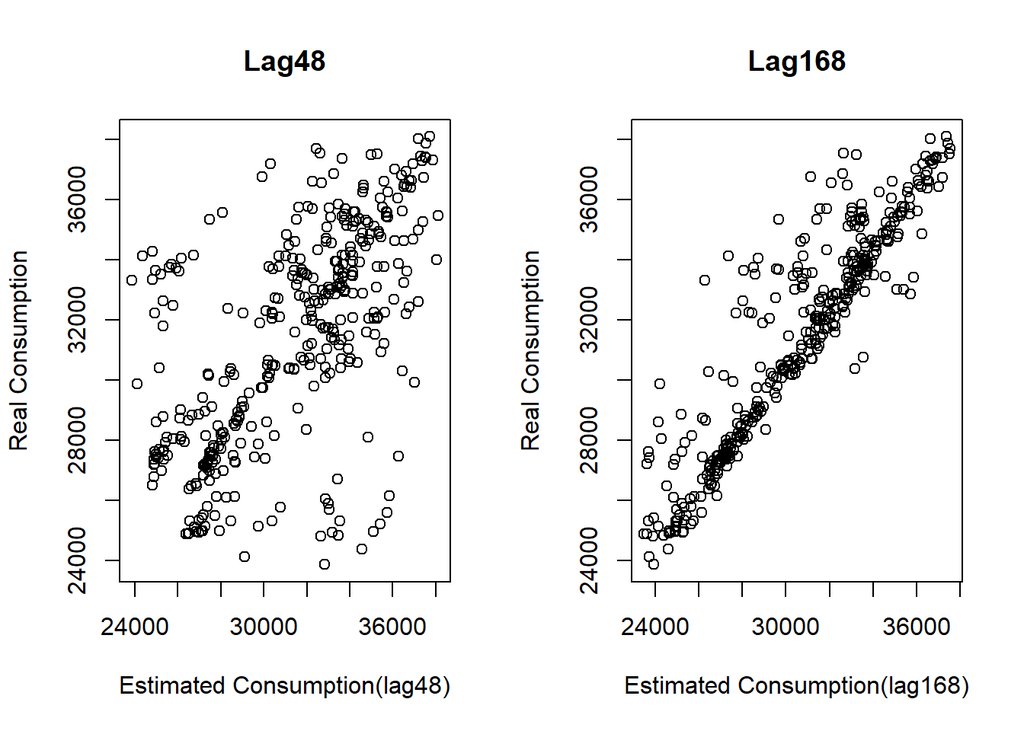

In addition, the plots also shows how scattered the values in the lag48 prediction method, whereas more linear trend is obtained with lag168 showing less variation.

#Task B The linear regressin model is built by taking lag48 and lag 168 as the features on the long format of the data. Hence, the model output is as follows;

```
    consumption=beta(0)+beta(1)xlag48+beta(2)xlag168
```

Where beta(0) is the intercept and beta(1) and beta(2) are the coefficients of the linear regression model. The summary of the linear regression is as follows:

```r
train_data<-cbind(training_data$lag48, training_data$lag168)
train_data<-data.frame(train_data)
train_results<-training_data$`Consumption (MWh)`
linear_regression=lm(train_results~., data=train_data)

summary(linear_regression)
```

```
##
## Call:
## lm(formula = train_results ~ ., data = train_data)
##
## Residuals:
##      Min       1Q   Median       3Q      Max
## -16784.6   -994.2      2.9   1022.4  15951.4
##
## Coefficients:
##              Estimate Std. Error t value Pr(>|t|)
## (Intercept) 1.624e+03  9.678e+01   16.78   <2e-16 ***
## X1          3.257e-01  3.520e-03   92.51   <2e-16 ***
## X2          6.246e-01  3.518e-03  177.51   <2e-16 ***
## ---
## Signif. codes:  0 '***' 0.001 '**' 0.01 '*' 0.05 '.' 0.1 ' ' 1
##
## Residual standard error: 2403 on 33405 degrees of freedom
## Multiple R-squared:  0.7627, Adjusted R-squared:  0.7627
## F-statistic: 5.368e+04 on 2 and 33405 DF,  p-value: < 2.2e-16
```

These results can be interpreted from the figures as well.

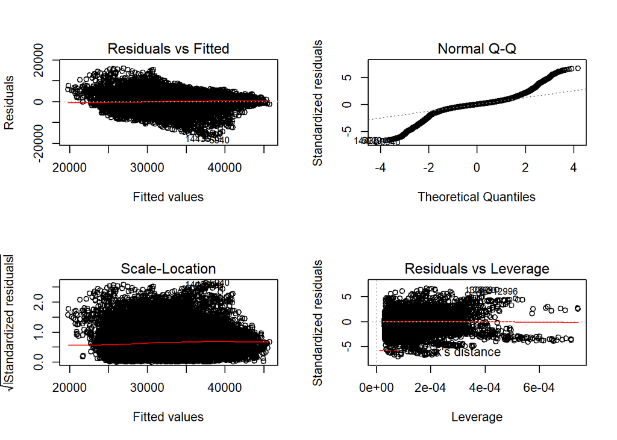

```
## [1] 3.923952
```

The MAPE result is found to be 3.92 for this case. This result is slighly higher than the MAPE obtained in task A with lag168. This can be explained by the regression model itself. Here, the same coefficients for each hour are used to estimate the consumption values. However, there is less electiricity consumption in the night hours. This, may increase the MAPE value.

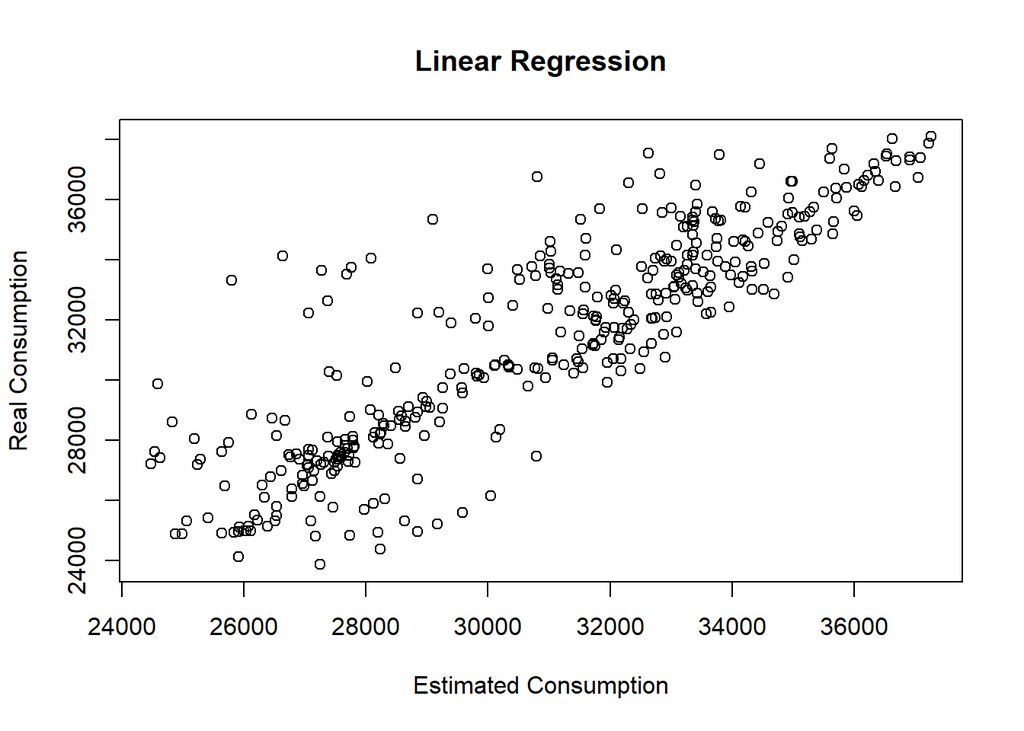

#TASK C

Due to the hourly seasonality explained in previous section, 24 different models are trained to take hour affect on the consumption amount into consideration.

```
##    hourly_mape
## 1     4.870455
## 2     4.941637
## 3     5.029088
## 4     5.064485
## 5     5.017809
## 6     4.918092
## 7     4.625368
## 8     4.089377
## 9     3.542047
## 10    3.643351
## 11    3.845276
## 12    4.019133
## 13    4.077260
## 14    4.229196
## 15    4.118281
## 16    4.068659
## 17    4.007485
## 18    3.981786
## 19    4.234983
## 20    4.527888
## 21    4.555264
## 22    4.619078
## 23    4.713784
## 24    4.708940
```

[figure not shown]

```r
#modelling each hour by performing 24 separate models
date_train<-unique(training_data$Date)
hour_days<-unique(training_data$Hour)
linear_regression<-c()
hourly_coeff<-c()
hourly_mape<-c()

for(i in 1:24){
  trainhour_data<-filter(training_data, Hour==hour_days[i])
  trainhour_data_x<-cbind(trainhour_data[,5], trainhour_data[,6])
  trainhour_data_x<-data.frame(trainhour_data_x)
  train_results<-trainhour_data[,3]
  linear_regression<-lm(train_results~.,data=trainhour_data_x)

  hourly_coeff[[i]]<-as.matrix(linear_regression$coefficients)

  testinghour_data<-filter(testing_data, Hour==hour_days[i])
  testing_df<-data.frame(testing_data[,1:6])
  names(testing_df)[5] <- "X1"
  names(testing_df)[6] <- "X2"
  testing_df$Estimate <- predict(linear_regression,testing_df)
  hourly_mape[i]<-mape(testing_df$Estimate,testing_df$Consumption..MWh.)

}

hourly_coeff_df <- data.frame(matrix(unlist(hourly_coeff), nrow=length(hourly_coeff), byrow=T))
hourly_mape<-data.frame(hourly_mape)
hourly_mape
```

#TASK D

Here, the data table is transformed from long format to wide format to use the 24 h data for both lag48 and lag168 as the predictors. For example, to predict 18 September electricity consumption at 18:00, the all day electiricty consumption of 16 September and 11 September are used as the parameters, hence there are 48 features. However, these 48 h consumption values are highly correlated. Therefore, penalized regression, more specifically lasso regression is used in this part.

```r
#To be sure that the training and the testing data are original

training_data<-filter(all_data, Date<="2019-10-31")
testing_data<-filter(all_data, Date>"2019-10-31")
#removing zeros for lag 48 and lag 168
training_data<-filter(training_data, Date>"2016-01-07")

#Transforming to wide format for train data
w<-dcast(training_data,Date~ Hour, value.var="lag48")
w2<-dcast(training_data,Date~ Hour, value.var="lag168")
wide_training_data<-cbind(w, w2[,2:25])
names(wide_training_data)[-1] <-  paste0('x', 1:(ncol(wide_training_data)))

#Transforming to wide format for test data
w_test<-dcast(testing_data,Date~ Hour, value.var="lag48")
w2_test<-dcast(testing_data,Date~ Hour, value.var="lag168")
wide_testing_data<-cbind(w_test, w2_test[,2:25])
names(wide_testing_data)[-1] <-  paste0('x', 1:(ncol(wide_testing_data)))
```

The features of the training data is the same for all the hours, because only the target consumption is changing according to the hourly production. Hence, after forming the tables in wide format, the target values and corresponding test data are chosed with the help of for loop.

```r
#####Creating hourly Lasso regression
date_train<-unique(training_data$Date)
hour_days<-unique(training_data$Hour)
hourly_coeff_lasso<-c()
hourly_mape_lasso<-c()
bestlam<-c()

for(i in 1:24){

  wide_train_y<-filter(training_data, Hour == hour_days[i])
  wide_test_y<-filter(testing_data, Hour == hour_days[i])
  ###################################################
  wide_train_y<-wide_train_y$`Consumption (MWh)`
  figure_2<-cbind(wide_training_data,wide_train_y)

  train_data<-as.matrix(wide_training_data[,2:49])
  train_results<-as.matrix(wide_train_y)
  testing_m<-data.matrix(wide_testing_data[,1:49])

  ##########lasso regression
  cv_output<-cv.glmnet(train_data, train_results, family = "gaussian", alpha = 1)

  bestlam[i]=cv_output$lambda.min
  lasso_best<-glmnet(train_data, train_results, family = "gaussian", alpha = 1, lambda = bestlam)
  wide_testing_data$Lasso_pred<-predict(lasso_best, newx =  as(testing_m[,2:49], "dgCMatrix"), type = "response")

  hourly_mape_lasso[i]<-mape(wide_testing_data$Lasso_pred[,1],wide_test_y$`Consumption (MWh)`)

}

hourly_mape_lasso<-data.frame(hourly_mape_lasso)
hourly_mape_lasso
```

```
##    hourly_mape_lasso
## 1           1.933436
## 2           1.954749
## 3           1.970729
## 4           1.946134
## 5           1.797059
## 6           1.697007
## 7           1.562289
## 8           1.896063
## 9           2.662705
## 10          3.277045
## 11          3.360768
## 12          3.421328
## 13          3.788950
## 14          3.765578
## 15          3.940231
## 16          3.525444
## 17          2.951152
## 18          2.501635
## 19          2.165225
## 20          2.081507
## 21          1.679232
## 22          1.791455
## 23          1.833817
## 24          1.763794
```

#TASK E

The results of lasso regression with the linear regression is compared in this section with box plot. Boxplots are a measure of how well distributed is the data in a data set. As can be seen from the figure, Lasso regression has smaller median but higher interqualtile range compared to linear regression. This shows that linear regression prodives lower variance whereas lasso regression prvides higher accuracy.

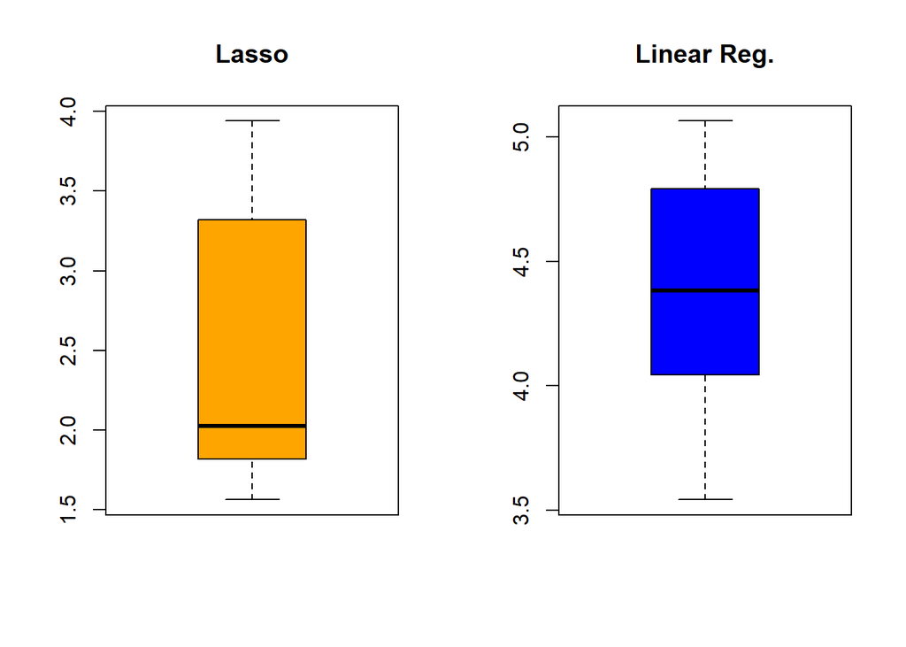

```r
par(mfrow=c(1,2))
boxplot(hourly_mape_lasso, col = "orange", main="Lasso")
boxplot(hourly_mape, col = "blue", main="Linear Reg.")
```